# Ramadurai_Quiz1

Samyuktha

2024-10-11

# Note on using Google and ChatGPT

Hi Sabrina, here is my quiz! I mostly did the questions on my own, with some help from R help pages and previous homework. I Googled a few things, and these instances (1,2,3,4) are mentioned in the text or in code chunks as comments. I used ChatGPT to proofread one of my code chucks (5).

# Swallows Dataset

## Importing and viewing raw data

```r
library(dplyr)
library(dslabs)
library(tidyverse)
```

Load swallows.csv and brightness.csv

```r
swallows <- read.csv('swallows.csv')
plumage <- read.csv('brightness.csv')
View(swallows)
View(plumage)
```

## Data Wrangling

### Combining swallows and plumage

We want to combine the two datasets.The order of the nest-ids is different in both the datasets, so we should write a script that compares the row number in plumage and swallows in which the nest-box values are the same, and adds the corresponding brightness value to the dataframe. For example, row-1 in swallows has the nest-box value of 2_124, and this corresponds to row-17 in plumage (since it has the same nest-box value). So, I would want to add the brightness value in row-17 of plumage to row-1 of swallows (in a newly created column for brightness).

[1] For the code below, I googled the basic syntax for the “for” loop, since I missed the “{}” in the syntax provided in the R help page. I also googled the function “cat”, which concatenates and prints two or more variables together. I found this to be more convenient to use for this code compared to the regular print function.

```r
brightness_ordered <- c(); #empty vector that I will add elements to in the loop

for (x in 1:42){   #row numbers in swallows
  for (y in 1:42){  #row numbers in plumage --> Fixes x and iterates over y.
    if(swallows$nestbox[x] == plumage$nestbox[y]){  #check if the row numbers are equal.
      brightness_ordered <- append(brightness_ordered, plumage$brightness[y]) #add brightness value at y to the empty list. The x-th element is added.
#     cat("(",x,",",y,")","\n") This is a concatenate and print function, and can be used to check if this code block correctly identifies the row numbers in swallows and plumage for the same nest-box values.
    }
  }
}

print(brightness_ordered) #This is the final vector which gives us a list of brightness values that matches the order of the nest-box values in swallows.
```

```
##  [1] 58.4 57.7   NA 55.7 58.6 54.2 41.5 39.9 49.3 68.0 53.3 43.8 55.9 56.2 47.1
## [16] 49.2 57.0 57.4 33.9 48.2 49.0 62.6 34.1 57.0 59.2 48.1 50.6 41.2 54.5 60.2
## [31] 53.6 56.0 35.3 42.4 45.5 52.6 64.6 53.9 49.2 47.2 41.2 55.8
```

Now I can add this vector as a column in swallows.

```r
swallows <- swallows |>
  mutate(brightness_ordered)

View(swallows)
```

The only obvious entry error I noticed was an “NA”, but I think we can handle that.

### Creating a new column for the proportion of nestlings that fledged

```r
swallows <- swallows |>
  mutate(proportion_fledged = n_fledged/brood)
View(swallows)
```

There are several NaN values in this column, which makes sense because there were nests with no brood, so you cannot have a proportion for those nests(division by zero).

## Data Exploration

### Mean proportion of nestlings fledged in each treatment

I can do this using group_by or aggregate. But first, I need to get rid of the rows with the NaN values.

[2]

```r
swallows_with_brood <- swallows  #swallows_with_brood is the dataset for which the brood value is non-zero. I will intially set this to be the same as swallows.

for (x in 1:42){
  if(swallows$proportion_fledged[x] == 'NaN'){  #A better function to use here is "rows_to_delete <- which(is.nan(swallows$proportion_fledged))" (source: ChatGPT)
    swallows_with_brood[x, ] = swallows[-x,]   #swallows[-x,] deletes the -xth row in swallows (Googled this). So, swallows_with_brood gets these rows removed from it. (this does not alter the dataset swallows. In order to do that, we need swallows = swallows[-x, ]. But we don't want to do that because swallows should remain untouched.
  }
}
```

```
## Warning in `[<-.data.frame`(`*tmp*`, x, , value = structure(list(nestbox =
## c("2_124", : replacement element 5 has 41 rows to replace 1 rows
```

```
## Warning in `[<-.data.frame`(`*tmp*`, x, , value = structure(list(nestbox =
## c("2_124", : replacement element 6 has 41 rows to replace 1 rows
```

```r
View(swallows_with_brood)
```

(Used ChatGPT to proofread)[5]

I’m not sure what these warnings are about. It is a lot more efficient to use more R-specific methods, but I couldn’t remember how to manipulate rows with tidyverse. So, I did a Google search [3] and found a few more ways of doing this:

*Method-1: Using base R*

```r
swallows_with_brood_method1 <- swallows[swallows$proportion_fledged != 'NaN', ]
View(swallows_with_brood_method1)
```

*Method-2: Using ‘subset’*

```r
swallows_with_brood_method2 <- subset(swallows, proportion_fledged != 'NaN' )
View(swallows_with_brood_method2)
```

*Method-3: Using base R and is.nan*

```r
swallows_with_brood_method3 <-  swallows[!is.nan(swallows$proportion_fledged), ]
View(swallows_with_brood_method3)
```

Now, I can calculate the mean proportion fledged for each treatment.

```r
swallows_with_brood |>
  group_by(treatment) |>
  summarise(mean(proportion_fledged))
```

```
## # A tibble: 2 × 2
##   treatment `mean(proportion_fledged)`
##   <chr>                          <dbl>
## 1 Control                        0.652
## 2 Predation                      0.335
```

### Fledging success differences between treatments

[4]

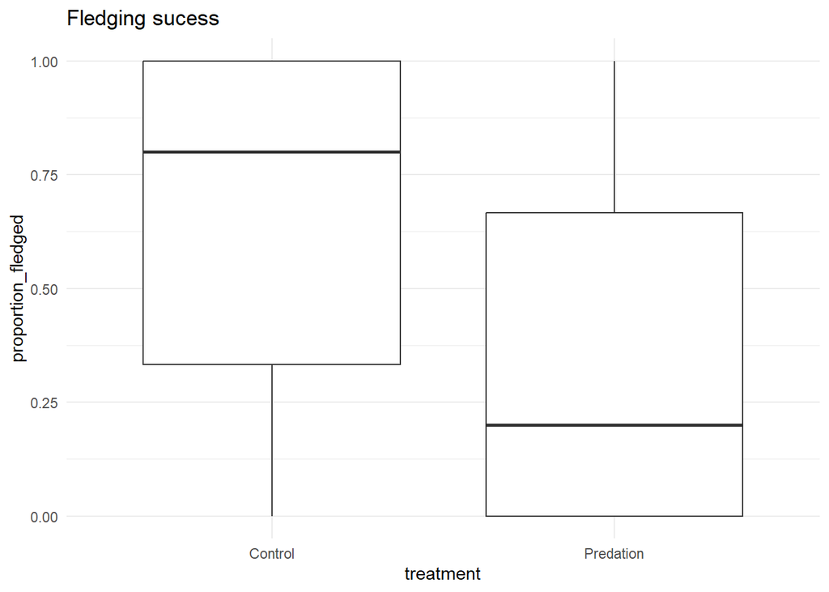

```r
fledging_success_plot <- ggplot(swallows_with_brood) +    #Used ggplot cheat sheet
  geom_boxplot(aes(x = treatment, y = proportion_fledged)) +
  labs(title = "Fledging sucess")+
  theme_minimal()
print(fledging_success_plot)
```

### Does female brightness influence fledging success?

We could investigate this by plotting brightness vs proportion fledged.

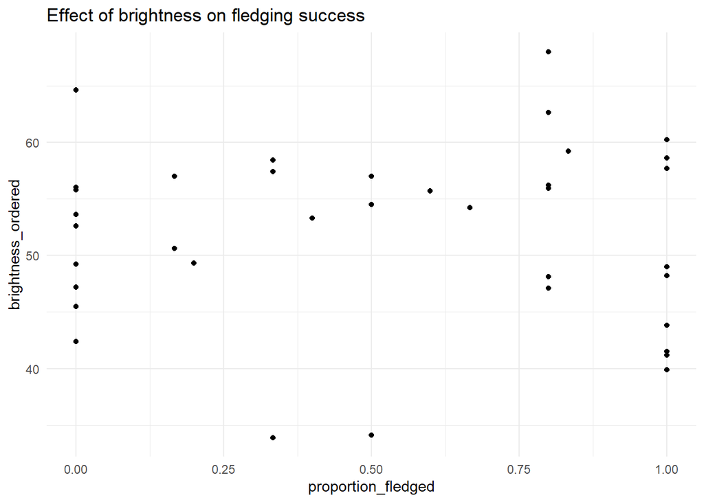

```r
brightness_fledging_plot <- ggplot(swallows_with_brood) +
  geom_point(aes(x = proportion_fledged, y = brightness_ordered)) +
  labs(title = "Effect of brightness on fledging success")+
  theme_minimal()
print(brightness_fledging_plot)
```

From the plot, it looks like female brightness does not influence fledging success. There are more data points for brighter birds, and so there is a greater spread for brightness values over 50.

But female brightness could influence the number of brood, so let’s check that.

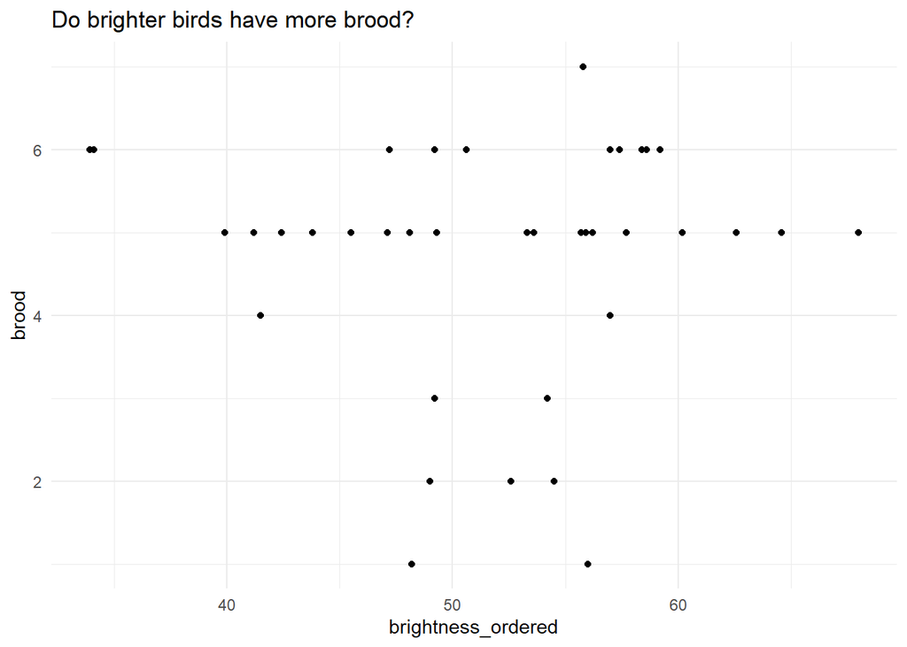

```r
brightness_brood_plot <- ggplot(swallows_with_brood) +
  geom_point(aes(x = brightness_ordered, y = brood)) +
  labs(title = "Do brighter birds have more brood?")+
  theme_minimal()
print(brightness_brood_plot)
```

This also does no seem to be the case. So the brightness of female birds may not be as important as other factors (like maybe male brightness) in determining the success of their offspring.